# Course Project: Practical Machine Learning

Nikhila Arkalgud

January 29, 2016

Introduction

Using devices such as Jawbone Up, Nike FuelBand, and Fitbit it is now possible to collect a large amount of data about personal activity relatively inexpensively. These type of devices are part of the quantified self movement – a group of enthusiasts who take measurements about themselves regularly to improve their health, to find patterns in their behavior, or because they are tech geeks. One thing that people regularly do is quantify how much of a particular activity they do, but they rarely quantify how well they do it. In this project, your goal will be to use data from accelerometers on the belt, forearm, arm, and dumbell of 6 participants. They were asked to perform barbell lifts correctly and incorrectly in 5 different ways. More information is available from the website here: http://groupware.les.inf.puc-rio.br/har (see the section on the Weight Lifting Exercise Dataset). http://groupware.les.inf.puc-rio.br/har

Data Sets

The training data for this project are available here:

https://d396qusza40orc.cloudfront.net/predmachlearn/pml-training.csv

The test data are available here:

https://d396qusza40orc.cloudfront.net/predmachlearn/pml-testing.csv

The data for this project come from this source: http://groupware.les.inf.puc-rio.br/har. If you use the document you create for this class for any purpose please cite them as they have been very generous in allowing their data to be used for this kind of assignment.

Data Preparation

We will load the data and the 20 cases that will be submitted to coursera. Download the pml-training.csv and pml-testing.csv files from http://d396qusza40orc.cloudfront.net/predmachlearn

```r
pmltraining <- read.csv("http://d396qusza40orc.cloudfront.net/predmachlearn/pml-training.csv", sep=",", na.strings=c("","NA"))
pmltesting <- read.csv("http://d396qusza40orc.cloudfront.net/predmachlearn/pml-testing.csv", sep=",", na.strings=c("","NA"))
```

Data Cleaning

We will remove columns with NAs and only use features used in the test set

```r
pmltesting1 <- pmltesting[1:159] # temporarily remove last column problem_id from test set
features <- names(pmltesting1[,colSums(is.na(pmltesting1)) == 0]) # check for NA
pmltraining <- pmltraining[,c(features,"classe")] # select only non NA features and include classe column
pmltesting <- pmltesting[,c(features,"problem_id")] # select only non NA features and include problem_id column
```

Data Separation

We will use divide training data set into 75% to train and 25% to test to fit a model.

```r
set.seed(235)
library(caret)
inTrain <- createDataPartition(pmltraining$classe, p = 0.75, list = F)
train <- pmltraining[inTrain,]
test <- pmltraining[-inTrain,]
```

Feature Selection

We will remove the high correlation features > 90%

```r
outcome <- which(names(train)=="classe")
train_numeric <- train[sapply(train,is.numeric)]
highCorrCols <- findCorrelation(abs(cor(train_numeric[,-outcome])),0.9)
highCorFea <- names(train[highCorrCols])
train <- train[,-highCorrCols] # remove the high correlation features
```

Features with high correlation are

```r
highCorFea
```

```
## [1] "gyros_belt_z"   "cvtd_timestamp" "gyros_belt_y"   "gyros_belt_x"
## [5] "pitch_arm"
```

Now we will find out the most important features using Random Forest. The feature plot shows the topmost 4 features

```r
library(randomForest)
```

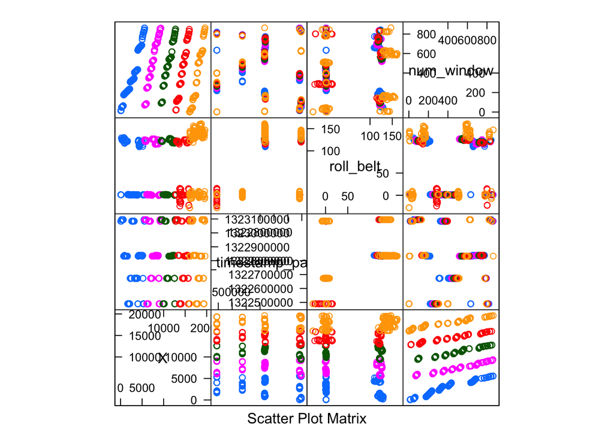

```r
outcome <- which(names(train)=="classe")
rf_fs <- randomForest(train[,-outcome], train[,outcome], importance = T)
rf_imp <- data.frame(rf_fs$importance)
keyFeatures <- order(-rf_imp$MeanDecreaseGini)
inImp = createDataPartition(pmltraining$classe, p = 0.05, list = F)
featurePlot(train[inImp,keyFeatures[1:4]],train$classe[inImp], plot = "pairs")
```

The most important features are

```r
kfnames <- names(train[keyFeatures[1:4]])
kfnames
```

```
## [1] "X"                    "raw_timestamp_part_1" "roll_belt"
## [4] "num_window"
```

create a new train set with top 4 key features and include last column classe

```r
train_new <- train[,c(keyFeatures[1:4],ncol(train))]
```

Training

I will training the dataset using two different classifiers, Random Forest and Boosting Algorithm

Method Random Forest

```r
crf <- trainControl(method="oob")
mrf <- train(classe ~ . , train_new, method = "rf", trControl = crf)
```

Method Boosting Algorithms

```r
cb <- trainControl(method="repeatedcv", number = 5, repeats = 1)
mb <- train(classe ~ . , train_new, method = "gbm", trControl = cb, verbose = FALSE)
```

Compare the results

```r
fitrf <- predict(mrf,test)
fitb <- predict(mb,test)
```

Confusion matrix for RF vs Test Set

```r
confusionMatrix(fitrf,test[,"classe"])
```

```
## Confusion Matrix and Statistics
##
##           Reference
## Prediction    A    B    C    D    E
##          A 1395    0    0    0    0
##          B    0  949    1    0    0
##          C    0    0  854    0    0
##          D    0    0    0  804    0
##          E    0    0    0    0  901
##
## Overall Statistics
##
##                Accuracy : 0.9998
##                  95% CI : (0.9989, 1)
##     No Information Rate : 0.2845
##     P-Value [Acc > NIR] : < 2.2e-16
##
##                   Kappa : 0.9997
##  Mcnemar's Test P-Value : NA
##
## Statistics by Class:
##
##                      Class: A Class: B Class: C Class: D Class: E
## Sensitivity            1.0000   1.0000   0.9988   1.0000   1.0000
## Specificity            1.0000   0.9997   1.0000   1.0000   1.0000
## Pos Pred Value         1.0000   0.9989   1.0000   1.0000   1.0000
## Neg Pred Value         1.0000   1.0000   0.9998   1.0000   1.0000
## Prevalence             0.2845   0.1935   0.1743   0.1639   0.1837
## Detection Rate         0.2845   0.1935   0.1741   0.1639   0.1837
## Detection Prevalence   0.2845   0.1937   0.1741   0.1639   0.1837
## Balanced Accuracy      1.0000   0.9999   0.9994   1.0000   1.0000
```

Confusion matrix for Bossting Algorithms vs Test Set

```r
confusionMatrix(fitb,test[,"classe"])
```

```
## Confusion Matrix and Statistics
##
##           Reference
## Prediction    A    B    C    D    E
##          A 1395    0    0    0    0
##          B    0  949    0    0    0
##          C    0    0  855    0    0
##          D    0    0    0  804    0
##          E    0    0    0    0  901
##
## Overall Statistics
##
##                Accuracy : 1
##                  95% CI : (0.9992, 1)
##     No Information Rate : 0.2845
##     P-Value [Acc > NIR] : < 2.2e-16
##
##                   Kappa : 1
##  Mcnemar's Test P-Value : NA
##
## Statistics by Class:
##
##                      Class: A Class: B Class: C Class: D Class: E
## Sensitivity            1.0000   1.0000   1.0000   1.0000   1.0000
## Specificity            1.0000   1.0000   1.0000   1.0000   1.0000
## Pos Pred Value         1.0000   1.0000   1.0000   1.0000   1.0000
## Neg Pred Value         1.0000   1.0000   1.0000   1.0000   1.0000
## Prevalence             0.2845   0.1935   0.1743   0.1639   0.1837
## Detection Rate         0.2845   0.1935   0.1743   0.1639   0.1837
## Detection Prevalence   0.2845   0.1935   0.1743   0.1639   0.1837
## Balanced Accuracy      1.0000   1.0000   1.0000   1.0000   1.0000
```

Random Forest and Boosting did almost the same, predicting with an accuracy of 99.9%

Submit

I will use the Random Forest model created to predict on the final 20 cases submitted to Coursera

```r
submit <- predict(mrf,pmltesting)
```